# Project: Investigate a Medical Appointment No Shows Dataset

- Introduction
- Data Wrangling
- Exploratory Data Analysis
- Conclusions

Muhammad Adipurna Kusumawardana  
June 10th, 2020

## Introduction

> This dataset collects information from 100k medical appointments in Brazil and is focused on the question of whether or not patients show up for their appointment. A number of characteristics about the patient are included in each row.

**Data Dictionary** based on original dataset in [Kaggle](https://www.kaggle.com/joniarroba/noshowappointments).

**Question**  
What factors are important for us to know in order to predict if a patient will not show up for their scheduled appointment?

> Before proceed to the next step, firstly we need to import some useful modules that we are using in this project.
> 1. Numpy for scientific computing with Python.
> 2. Pandas as data manipulation and analytic tool for Python.
> 3. Matplotlib basic tool for making data visualization
> 4. Seaborn for beautifying the visualization

```python
# Import all important modules
#
import numpy as np
import pandas as pd
import matplotlib.pyplot as plt
import seaborn as sns

%matplotlib inline
```

## Data Wrangling

> In this section we will do some data preparation, such as:
> - Load in the data  
>   The [data](https://www.google.com/url?q=https://d17h27t6h515a5.cloudfront.net/topher/2017/October/59dd2e9a_noshowappointments-kagglev2-may-2016/noshowappointments-kagglev2-may-2016.csv&sa=D&ust=1532469042118000) is already provided from Udacity Team, is cleaner than the original data in Kaggle.
> - Check for cleanliness
> - Trim and clean our dataset for analysis.

### General Properties

```python
# Load in data and print out a few lines
#
df = pd.read_csv('noshowappointments-kagglev2-may-2016.csv')
df
```

|  | PatientId | AppointmentID | Gender | ScheduledDay | AppointmentDay | Age | Neighbourhood | Scholarship | Hipertension | Diabetes | Alcoholism | Handcap | SMS_received | No-show |
| --- | --- | --- | --- | --- | --- | --- | --- | --- | --- | --- | --- | --- | --- | --- |
| 0 | 2.987250e+13 | 5642903 | F | 2016-04-29T18:38:08Z | 2016-04-29T00:00:00Z | 62 | JARDIM DA PENHA | 0 | 1 | 0 | 0 | 0 | 0 | No |
| 1 | 5.589978e+14 | 5642503 | M | 2016-04-29T16:08:27Z | 2016-04-29T00:00:00Z | 56 | JARDIM DA PENHA | 0 | 0 | 0 | 0 | 0 | 0 | No |
| 2 | 4.262962e+12 | 5642549 | F | 2016-04-29T16:19:04Z | 2016-04-29T00:00:00Z | 62 | MATA DA PRAIA | 0 | 0 | 0 | 0 | 0 | 0 | No |
| 3 | 8.679512e+11 | 5642828 | F | 2016-04-29T17:29:31Z | 2016-04-29T00:00:00Z | 8 | PONTAL DE CAMBURI | 0 | 0 | 0 | 0 | 0 | 0 | No |
| 4 | 8.841186e+12 | 5642494 | F | 2016-04-29T16:07:23Z | 2016-04-29T00:00:00Z | 56 | JARDIM DA PENHA | 0 | 1 | 1 | 0 | 0 | 0 | No |
| ... | ... | ... | ... | ... | ... | ... | ... | ... | ... | ... | ... | ... | ... | ... |
| 110522 | 2.572134e+12 | 5651768 | F | 2016-05-03T09:15:35Z | 2016-06-07T00:00:00Z | 56 | MARIA ORTIZ | 0 | 0 | 0 | 0 | 0 | 1 | No |
| 110523 | 3.596266e+12 | 5650093 | F | 2016-05-03T07:27:33Z | 2016-06-07T00:00:00Z | 51 | MARIA ORTIZ | 0 | 0 | 0 | 0 | 0 | 1 | No |
| 110524 | 1.557663e+13 | 5630692 | F | 2016-04-27T16:03:52Z | 2016-06-07T00:00:00Z | 21 | MARIA ORTIZ | 0 | 0 | 0 | 0 | 0 | 1 | No |
| 110525 | 9.213493e+13 | 5630323 | F | 2016-04-27T15:09:23Z | 2016-06-07T00:00:00Z | 38 | MARIA ORTIZ | 0 | 0 | 0 | 0 | 0 | 1 | No |
| 110526 | 3.775115e+14 | 5629448 | F | 2016-04-27T13:30:56Z | 2016-06-07T00:00:00Z | 54 | MARIA ORTIZ | 0 | 0 | 0 | 0 | 0 | 1 | No |

110527 rows × 14 columns

> From the CSV file *noshowappointments-kagglev2-may-2016.csv*, we got the data frame which has 110527 rows and 14 columns (as stated in dataset dictionary)

> Then, we want to see the information from this data frame, from this we can know if there is missing data in it.

```python
# Perform operations to inspect data types and look for instances of missing or possibly errant data.
#
df.info()
```

```
<class 'pandas.core.frame.DataFrame'>
RangeIndex: 110527 entries, 0 to 110526
Data columns (total 14 columns):
 #   Column          Non-Null Count   Dtype
---  ------          --------------   -----
 0   PatientId       110527 non-null  float64
 1   AppointmentID   110527 non-null  int64
 2   Gender          110527 non-null  object
 3   ScheduledDay    110527 non-null  object
 4   AppointmentDay  110527 non-null  object
 5   Age             110527 non-null  int64
 6   Neighbourhood   110527 non-null  object
 7   Scholarship     110527 non-null  int64
 8   Hipertension    110527 non-null  int64
 9   Diabetes        110527 non-null  int64
 10  Alcoholism      110527 non-null  int64
 11  Handcap         110527 non-null  int64
 12  SMS_received    110527 non-null  int64
 13  No-show         110527 non-null  object
dtypes: float64(1), int64(8), object(5)
memory usage: 11.8+ MB
```

> - The data frame contains no missing value.
> - Columns name is pretty consistent with *title* style. For easier to query, we will transform it into lower style
> - The PatientId should be in object data type, to prevent it from the calculation
> - The ScheduledDay and AppointmentDay should be in DateTime data type, maybe we should add the time span columns too.

### Explore Column Unique Values

> First, we need to determine what columns we should explore. Since 'PatientId', 'AppointmentID', 'ScheduledDay' and 'AppointmentDay' mostly unique for each rows, we should skip these columns.

```python
df.columns
```

```
Index(['PatientId', 'AppointmentID', 'Gender', 'ScheduledDay',
       'AppointmentDay', 'Age', 'Neighbourhood', 'Scholarship', 'Hipertension',
       'Diabetes', 'Alcoholism', 'Handcap', 'SMS_received', 'No-show'],
      dtype='object')
```

```python
# Exploring the unique values from each columns
#

cols = ['Gender', 'Age', 'Neighbourhood', 'Scholarship', 'Hipertension', 'Diabetes', 'Alcoholism', 'Handcap', 'SMS_received', 'No-show']

for c in cols:
    unique = sorted(df[c].unique())
    print(c, unique, '\n', sep='\n')
```

```
Gender
['F', 'M']


Age
[-1, 0, 1, 2, 3, 4, 5, 6, 7, 8, 9, 10, 11, 12, 13, 14, 15, 16, 17, 18, 19, 20, 21, 22, 23, 24, 25, 26, 27, 28, 29, 30, 31, 32, 33, 34, 35, 36, 37, 38, 39, 40, 41, 42, 43, 44, 45, 46, 47, 48, 49, 50, 51, 52, 53, 54, 55, 56, 57, 58, 59, 60, 61, 62, 63, 64, 65, 66, 67, 68, 69, 70, 71, 72, 73, 74, 75, 7…


Neighbourhood
['AEROPORTO', 'ANDORINHAS', 'ANTÔNIO HONÓRIO', 'ARIOVALDO FAVALESSA', 'BARRO VERMELHO', 'BELA VISTA', 'BENTO FERREIRA', 'BOA VISTA', 'BONFIM', 'CARATOÍRA', 'CENTRO', 'COMDUSA', 'CONQUISTA', 'CONSOLAÇÃO', 'CRUZAMENTO', 'DA PENHA', 'DE LOURDES', 'DO CABRAL', 'DO MOSCOSO', 'DO QUADRO', 'ENSEADA DO SUÁ'…


Scholarship
[0, 1]


Hipertension
[0, 1]


Diabetes
[0, 1]


Alcoholism
[0, 1]


Handcap
[0, 1, 2, 3, 4]


SMS_received
[0, 1]


No-show
['No', 'Yes']
```

> In the next step, we have to change the handicap and no-show column values to binary values.

### Data Cleaning

#### Renaming the Columns

> The columns name use combination of capital letters, it makes the data manipulation more difficult. We should change it into a lower style. Then for improving readability, we add underscore in the non-single string column.

```python
# Rename the columns into lower style
#
df.rename(columns=lambda x: x.lower(), inplace=True)

# Add underscore to improve readibility
#
df.rename(columns={'patientid':'patient_id',
                   'appointmentid':'appointment_id',
                   'scheduledday':'scheduled_day',
                   'appointmentday':'appointment_day',
                   'no-show':'no_show'},
         inplace=True)
df.head(5)
```

|  | patient_id | appointment_id | gender | scheduled_day | appointment_day | age | neighbourhood | scholarship | hipertension | diabetes | alcoholism | handcap | sms_received | no_show |
| --- | --- | --- | --- | --- | --- | --- | --- | --- | --- | --- | --- | --- | --- | --- |
| 0 | 2.987250e+13 | 5642903 | F | 2016-04-29T18:38:08Z | 2016-04-29T00:00:00Z | 62 | JARDIM DA PENHA | 0 | 1 | 0 | 0 | 0 | 0 | No |
| 1 | 5.589978e+14 | 5642503 | M | 2016-04-29T16:08:27Z | 2016-04-29T00:00:00Z | 56 | JARDIM DA PENHA | 0 | 0 | 0 | 0 | 0 | 0 | No |
| 2 | 4.262962e+12 | 5642549 | F | 2016-04-29T16:19:04Z | 2016-04-29T00:00:00Z | 62 | MATA DA PRAIA | 0 | 0 | 0 | 0 | 0 | 0 | No |
| 3 | 8.679512e+11 | 5642828 | F | 2016-04-29T17:29:31Z | 2016-04-29T00:00:00Z | 8 | PONTAL DE CAMBURI | 0 | 0 | 0 | 0 | 0 | 0 | No |
| 4 | 8.841186e+12 | 5642494 | F | 2016-04-29T16:07:23Z | 2016-04-29T00:00:00Z | 56 | JARDIM DA PENHA | 0 | 1 | 1 | 0 | 0 | 0 | No |

#### Drop appointment_id Column

> I think we do not need the appointment_id column because it will be different for each row. Also, we cant be certain enough to get some insight from it, analysis will be better if we use the DateTime-based column.

```python
df.drop('appointment_id', axis=1, inplace=True)
df.head(0)
```

|  | patient_id | gender | scheduled_day | appointment_day | age | neighbourhood | scholarship | hipertension | diabetes | alcoholism | handcap | sms_received | no_show |
| --- | --- | --- | --- | --- | --- | --- | --- | --- | --- | --- | --- | --- | --- |

#### Data Type Casting

> The patient_id column is not intended to be calculated, so, we cast it into object data type.

```python
# patient_id into object type
#
df.patient_id = df.patient_id.apply(lambda pid : str(int(pid)))
```

> For scheduled_day and appointment_day, as the data inside it has been formatted in DateTime, we cast it into DateTime data type.

```python
# scheduledday and appointmentday into datetime type
#
df.scheduled_day = pd.to_datetime(df.scheduled_day)
df.appointment_day = pd.to_datetime(df.appointment_day)
```

> For assure, we check using .info() method

```python
df.info()
```

```
<class 'pandas.core.frame.DataFrame'>
RangeIndex: 110527 entries, 0 to 110526
Data columns (total 13 columns):
 #   Column           Non-Null Count   Dtype
---  ------           --------------   -----
 0   patient_id       110527 non-null  object
 1   gender           110527 non-null  object
 2   scheduled_day    110527 non-null  datetime64[ns, UTC]
 3   appointment_day  110527 non-null  datetime64[ns, UTC]
 4   age              110527 non-null  int64
 5   neighbourhood    110527 non-null  object
 6   scholarship      110527 non-null  int64
 7   hipertension     110527 non-null  int64
 8   diabetes         110527 non-null  int64
 9   alcoholism       110527 non-null  int64
 10  handcap          110527 non-null  int64
 11  sms_received     110527 non-null  int64
 12  no_show          110527 non-null  object
dtypes: datetime64[ns, UTC](2), int64(7), object(4)
memory usage: 11.0+ MB
```

#### Categorical Data

> We' will convert the handicap and no-show column into binary categorical data.

As for the handicap column, we will convert values more than one into 1.

```python
# Before applying conversion
#
df.handcap.unique()
```

```
array([0, 1, 2, 3, 4], dtype=int64)
```

```python
# Make filter
#
handcap_1 = df.handcap > 1

# Applying value to filtered row
#
df.loc[handcap_1, 'handcap'] = 1

df.handcap.unique()
```

```
array([0, 1], dtype=int64)
```

#### Adding some New Columns

We can get time_span value with decreasing appointment_day by scheduled_day.

```python
df['time_span'] = df.appointment_day - df.scheduled_day
df['time_span'] = df['time_span'].abs().dt.days
df
```

|  | patient_id | gender | scheduled_day | appointment_day | age | neighbourhood | scholarship | hipertension | diabetes | alcoholism | handcap | sms_received | no_show | time_span |
| --- | --- | --- | --- | --- | --- | --- | --- | --- | --- | --- | --- | --- | --- | --- |
| 0 | 29872499824296 | F | 2016-04-29 18:38:08+00:00 | 2016-04-29 00:00:00+00:00 | 62 | JARDIM DA PENHA | 0 | 1 | 0 | 0 | 0 | 0 | No | 0 |
| 1 | 558997776694438 | M | 2016-04-29 16:08:27+00:00 | 2016-04-29 00:00:00+00:00 | 56 | JARDIM DA PENHA | 0 | 0 | 0 | 0 | 0 | 0 | No | 0 |
| 2 | 4262962299951 | F | 2016-04-29 16:19:04+00:00 | 2016-04-29 00:00:00+00:00 | 62 | MATA DA PRAIA | 0 | 0 | 0 | 0 | 0 | 0 | No | 0 |
| 3 | 867951213174 | F | 2016-04-29 17:29:31+00:00 | 2016-04-29 00:00:00+00:00 | 8 | PONTAL DE CAMBURI | 0 | 0 | 0 | 0 | 0 | 0 | No | 0 |
| 4 | 8841186448183 | F | 2016-04-29 16:07:23+00:00 | 2016-04-29 00:00:00+00:00 | 56 | JARDIM DA PENHA | 0 | 1 | 1 | 0 | 0 | 0 | No | 0 |
| ... | ... | ... | ... | ... | ... | ... | ... | ... | ... | ... | ... | ... | ... | ... |
| 110522 | 2572134369293 | F | 2016-05-03 09:15:35+00:00 | 2016-06-07 00:00:00+00:00 | 56 | MARIA ORTIZ | 0 | 0 | 0 | 0 | 0 | 1 | No | 34 |
| 110523 | 3596266328735 | F | 2016-05-03 07:27:33+00:00 | 2016-06-07 00:00:00+00:00 | 51 | MARIA ORTIZ | 0 | 0 | 0 | 0 | 0 | 1 | No | 34 |
| 110524 | 15576631729893 | F | 2016-04-27 16:03:52+00:00 | 2016-06-07 00:00:00+00:00 | 21 | MARIA ORTIZ | 0 | 0 | 0 | 0 | 0 | 1 | No | 40 |
| 110525 | 92134931435557 | F | 2016-04-27 15:09:23+00:00 | 2016-06-07 00:00:00+00:00 | 38 | MARIA ORTIZ | 0 | 0 | 0 | 0 | 0 | 1 | No | 40 |
| 110526 | 377511518121127 | F | 2016-04-27 13:30:56+00:00 | 2016-06-07 00:00:00+00:00 | 54 | MARIA ORTIZ | 0 | 0 | 0 | 0 | 0 | 1 | No | 40 |

110527 rows × 14 columns

Then, to get an appointment_weekday we can convert appointment_day DateTime into day name.

```python
df['appointment_weekday'] = df.appointment_day.map(lambda day : day.day_name())
df
```

|  | patient_id | gender | scheduled_day | appointment_day | age | neighbourhood | scholarship | hipertension | diabetes | alcoholism | handcap | sms_received | no_show | time_span | appointment_weekday |
| --- | --- | --- | --- | --- | --- | --- | --- | --- | --- | --- | --- | --- | --- | --- | --- |
| 0 | 29872499824296 | F | 2016-04-29 18:38:08+00:00 | 2016-04-29 00:00:00+00:00 | 62 | JARDIM DA PENHA | 0 | 1 | 0 | 0 | 0 | 0 | No | 0 | Friday |
| 1 | 558997776694438 | M | 2016-04-29 16:08:27+00:00 | 2016-04-29 00:00:00+00:00 | 56 | JARDIM DA PENHA | 0 | 0 | 0 | 0 | 0 | 0 | No | 0 | Friday |
| 2 | 4262962299951 | F | 2016-04-29 16:19:04+00:00 | 2016-04-29 00:00:00+00:00 | 62 | MATA DA PRAIA | 0 | 0 | 0 | 0 | 0 | 0 | No | 0 | Friday |
| 3 | 867951213174 | F | 2016-04-29 17:29:31+00:00 | 2016-04-29 00:00:00+00:00 | 8 | PONTAL DE CAMBURI | 0 | 0 | 0 | 0 | 0 | 0 | No | 0 | Friday |
| 4 | 8841186448183 | F | 2016-04-29 16:07:23+00:00 | 2016-04-29 00:00:00+00:00 | 56 | JARDIM DA PENHA | 0 | 1 | 1 | 0 | 0 | 0 | No | 0 | Friday |
| ... | ... | ... | ... | ... | ... | ... | ... | ... | ... | ... | ... | ... | ... | ... | ... |
| 110522 | 2572134369293 | F | 2016-05-03 09:15:35+00:00 | 2016-06-07 00:00:00+00:00 | 56 | MARIA ORTIZ | 0 | 0 | 0 | 0 | 0 | 1 | No | 34 | Tuesday |
| 110523 | 3596266328735 | F | 2016-05-03 07:27:33+00:00 | 2016-06-07 00:00:00+00:00 | 51 | MARIA ORTIZ | 0 | 0 | 0 | 0 | 0 | 1 | No | 34 | Tuesday |
| 110524 | 15576631729893 | F | 2016-04-27 16:03:52+00:00 | 2016-06-07 00:00:00+00:00 | 21 | MARIA ORTIZ | 0 | 0 | 0 | 0 | 0 | 1 | No | 40 | Tuesday |
| 110525 | 92134931435557 | F | 2016-04-27 15:09:23+00:00 | 2016-06-07 00:00:00+00:00 | 38 | MARIA ORTIZ | 0 | 0 | 0 | 0 | 0 | 1 | No | 40 | Tuesday |
| 110526 | 377511518121127 | F | 2016-04-27 13:30:56+00:00 | 2016-06-07 00:00:00+00:00 | 54 | MARIA ORTIZ | 0 | 0 | 0 | 0 | 0 | 1 | No | 40 | Tuesday |

110527 rows × 15 columns

#### Examine Weird Data

> Next, we need to examine from the summary statistic, to see if there is some weird data in it.

```python
df.describe()
```

|  | age | scholarship | hipertension | diabetes | alcoholism | handcap | sms_received | time_span |
| --- | --- | --- | --- | --- | --- | --- | --- | --- |
| count | 110527.000000 | 110527.000000 | 110527.000000 | 110527.000000 | 110527.000000 | 110527.000000 | 110527.000000 | 110527.000000 |
| mean | 37.088874 | 0.098266 | 0.197246 | 0.071865 | 0.030400 | 0.020276 | 0.321026 | 9.532829 |
| std | 23.110205 | 0.297675 | 0.397921 | 0.258265 | 0.171686 | 0.140942 | 0.466873 | 15.027683 |
| min | -1.000000 | 0.000000 | 0.000000 | 0.000000 | 0.000000 | 0.000000 | 0.000000 | 0.000000 |
| 25% | 18.000000 | 0.000000 | 0.000000 | 0.000000 | 0.000000 | 0.000000 | 0.000000 | 0.000000 |
| 50% | 37.000000 | 0.000000 | 0.000000 | 0.000000 | 0.000000 | 0.000000 | 0.000000 | 3.000000 |
| 75% | 55.000000 | 0.000000 | 0.000000 | 0.000000 | 0.000000 | 0.000000 | 1.000000 | 14.000000 |
| max | 115.000000 | 1.000000 | 1.000000 | 1.000000 | 1.000000 | 1.000000 | 1.000000 | 178.000000 |

> That's it. There is some weird data in the age column. The age is less than 0, is it possible?  
> We will examine it further.

```python
# Select the minus age row
df[df['age'] < 0]
```

|  | patient_id | gender | scheduled_day | appointment_day | age | neighbourhood | scholarship | hipertension | diabetes | alcoholism | handcap | sms_received | no_show | time_span | appointment_weekday |
| --- | --- | --- | --- | --- | --- | --- | --- | --- | --- | --- | --- | --- | --- | --- | --- |
| 99832 | 465943158731293 | F | 2016-06-06 08:58:13+00:00 | 2016-06-06 00:00:00+00:00 | -1 | ROMÃO | 0 | 0 | 0 | 0 | 0 | 0 | No | 0 | Monday |

> The patient with id number 465943158731293 has age -1. Since it just one row we will drop that row.

```python
df.drop(df.index[99832], inplace=True) # drop the desired index
df.reset_index(drop=True, inplace=True) # reset index
```

```python
df[df['age'] < 0]
```

|  | patient_id | gender | scheduled_day | appointment_day | age | neighbourhood | scholarship | hipertension | diabetes | alcoholism | handcap | sms_received | no_show | time_span | appointment_weekday |
| --- | --- | --- | --- | --- | --- | --- | --- | --- | --- | --- | --- | --- | --- | --- | --- |

```python
df.shape
```

```
(110526, 15)
```

> Notice that the row is decreased by one after dropping the weird data.

## Exploratory Data Analysis

> Now we have trimmed and cleaned our data, we're ready to take the next step. In the Exploratory Data Analysis section, we will compute the statistic and doing some basic data visualization. To reach our goal, we need to explore each variable.

> First, we need to look at our last data frame that has been cleaned before.

```python
df.head()
```

|  | patient_id | gender | scheduled_day | appointment_day | age | neighbourhood | scholarship | hipertension | diabetes | alcoholism | handcap | sms_received | no_show | time_span | appointment_weekday |
| --- | --- | --- | --- | --- | --- | --- | --- | --- | --- | --- | --- | --- | --- | --- | --- |
| 0 | 29872499824296 | F | 2016-04-29 18:38:08+00:00 | 2016-04-29 00:00:00+00:00 | 62 | JARDIM DA PENHA | 0 | 1 | 0 | 0 | 0 | 0 | No | 0 | Friday |
| 1 | 558997776694438 | M | 2016-04-29 16:08:27+00:00 | 2016-04-29 00:00:00+00:00 | 56 | JARDIM DA PENHA | 0 | 0 | 0 | 0 | 0 | 0 | No | 0 | Friday |
| 2 | 4262962299951 | F | 2016-04-29 16:19:04+00:00 | 2016-04-29 00:00:00+00:00 | 62 | MATA DA PRAIA | 0 | 0 | 0 | 0 | 0 | 0 | No | 0 | Friday |
| 3 | 867951213174 | F | 2016-04-29 17:29:31+00:00 | 2016-04-29 00:00:00+00:00 | 8 | PONTAL DE CAMBURI | 0 | 0 | 0 | 0 | 0 | 0 | No | 0 | Friday |
| 4 | 8841186448183 | F | 2016-04-29 16:07:23+00:00 | 2016-04-29 00:00:00+00:00 | 56 | JARDIM DA PENHA | 0 | 1 | 1 | 0 | 0 | 0 | No | 0 | Friday |

### How is the proportion of no_show column value?

> Before exploring further, we need to know the state of the data.

```python
# Show each sum value from no_show column
#
df.no_show.value_counts()
```

```
No     88207
Yes    22319
Name: no_show, dtype: int64
```

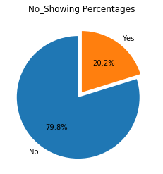

```python
# Plotting the above with pie chart
#
no_show = df.no_show.value_counts()
labels = ['No', 'Yes']

plt.pie(no_show, labels=labels, startangle=90, explode=[0.1, 0], autopct='%.1f%%')
plt.title('No_Showing Percentages')
plt.show()
```

> From the pie chart above, we can see that more than 20% percent of patients are not showing.

### How is data distribution?

> Then, we need to know how data is distributed. We are using the .hist() method on our data frame.

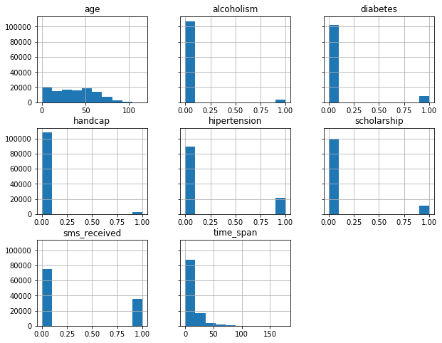

```python
df.hist(figsize=(10,8), sharey=True);
```

> From the bar plots and summary statistics above, mostly the patients are:
> - Under 60
> - Not alcoholism
> - Not in diabetes
> - Female in gender (as stated in the dictionary)
> - Have no handcap
> - Not in hipertension
> - Not in scholarship
> - Not received any SMS
> - Time span is equal and under two weeks

Too, from these bar plots, we know that some binary-value columns i.e, gender, scholarship, hipertension, diabetes, alcoholism, and handcap.

### Binary-Value Columns and no_snow Column

> Before exploring the binary-value columns, we need to make a crosstab function. This function will compute the frequency for each variable.

These binary-value columns are:

- gender
- scholarship
- hipertension
- diabetes
- alcoholism
- handcap
- sms_received

```python
def crosstab(index, column=df['no_show'], dataframe=df, sorter=False, ascending=False):
    """
    Compute a simple cross tabulation of two (or more) factors.
    By default computes a frequency table of the factors
    unless an array of values and an aggregation function are passed.
    https://pandas.pydata.org/pandas-docs/stable/reference/api/pandas.crosstab.html
    """
    df_cross = pd.crosstab(index, column).reset_index()

    df_cross['no_show_rate'] = df_cross['Yes'] / \
        (df_cross['No'] + df_cross['Yes']) * 100

    if sorter:
        df_cross.sort_values(by=['no_show_rate'], ignore_index=True, ascending=False, inplace=True)
        return df_cross
    else:
        return df_cross
```

> In this step we need to contain our binary-value columns into some container, such as a list. Then we iterate through that container while applying crosstab function on it.

```python
# Make list containing binary-value columns
#
binary_feature = ['gender', 'scholarship', 'hipertension', 'diabetes', 'alcoholism', 'handcap', 'sms_received']

# Iterate through list above, then add the absolute difference no_show value
#
for b in binary_feature:
    df_cross = crosstab(index=df[b], column=df.no_show)
    diff = df_cross.iloc[0][3] - df_cross.iloc[1][3]
    display(df_cross)
    print(b, 'difference rate= ', abs(diff), '% \n')
```

| no_show | gender | No | Yes | no_show_rate |
| --- | --- | --- | --- | --- |
| 0 | F | 57245 | 14594 | 20.314871 |
| 1 | M | 30962 | 7725 | 19.967948 |

```
gender difference rate=  0.34692286318332677 %
```

| no_show | scholarship | No | Yes | no_show_rate |
| --- | --- | --- | --- | --- |
| 0 | 0 | 79924 | 19741 | 19.807355 |
| 1 | 1 | 8283 | 2578 | 23.736304 |

```
scholarship difference rate=  3.928949569678256 %
```

| no_show | hipertension | No | Yes | no_show_rate |
| --- | --- | --- | --- | --- |
| 0 | 0 | 70178 | 18547 | 20.903917 |
| 1 | 1 | 18029 | 3772 | 17.301959 |

```
hipertension difference rate=  3.601957970473176 %
```

| no_show | diabetes | No | Yes | no_show_rate |
| --- | --- | --- | --- | --- |
| 0 | 0 | 81694 | 20889 | 20.363023 |
| 1 | 1 | 6513 | 1430 | 18.003273 |

```
diabetes difference rate=  2.359749790569172 %
```

| no_show | alcoholism | No | Yes | no_show_rate |
| --- | --- | --- | --- | --- |
| 0 | 0 | 85524 | 21642 | 20.194838 |
| 1 | 1 | 2683 | 677 | 20.148810 |

```
alcoholism difference rate=  0.046028391200831464 %
```

| no_show | handcap | No | Yes | no_show_rate |
| --- | --- | --- | --- | --- |
| 0 | 0 | 86373 | 21912 | 20.235490 |
| 1 | 1 | 1834 | 407 | 18.161535 |

```
handcap difference rate=  2.073954651006172 %
```

| no_show | sms_received | No | Yes | no_show_rate |
| --- | --- | --- | --- | --- |
| 0 | 0 | 62509 | 12535 | 16.703534 |
| 1 | 1 | 25698 | 9784 | 27.574545 |

```
sms_received difference rate=  10.871010912874034 %
```

> The difference rate is so small, for gender, scholarship, hipertension, diabetes, alcoholism, and handcap is no more than 5%. So we cannot use these variables for no_show deciding factor.

> Except for the sms_received column which the difference rate is more than 10%. Maybe we can use this as a deciding factor. Although it's kinda weird, the patient who received SMS showing that more no_show rate than non received SMS.

### Age

> Same as binary-value columns, we need to apply croostab function on age colum. Then plot the rate value into scatter plot to see the variable correlation.

```python
# Applying crosstab function to age column
#
df_age = crosstab(df['age'], column=df['no_show'], dataframe=df)
df_age.head()
```

| no_show | age | No | Yes | no_show_rate |
| --- | --- | --- | --- | --- |
| 0 | 0 | 2900 | 639 | 18.055948 |
| 1 | 1 | 1858 | 415 | 18.257809 |
| 2 | 2 | 1366 | 252 | 15.574784 |
| 3 | 3 | 1236 | 277 | 18.307997 |
| 4 | 4 | 1017 | 282 | 21.709007 |

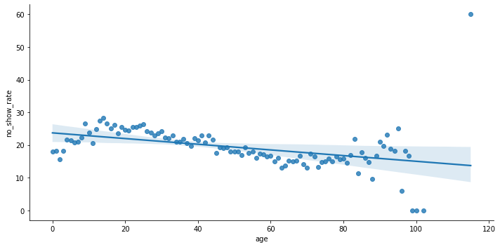

```python
# Plotting into scatter plot with regression line
#
sns.lmplot(data = df_age, x = 'age', y = 'no_show_rate', fit_reg = True, legend = True, aspect=2);
```

> The trend shows us that younger patients tend to not attend the appointment day. This trend is decreased along with the increasing age.

> At the most right of the plot, there is one point that has the highest no-show rate (age=115). This point is an outlier as shown in the following boxplot, so we can ignore it.

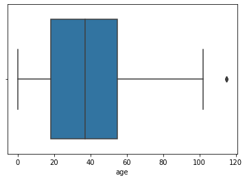

```python
sns.boxplot(x=df.age)
```

### Time Span

> In Data Cleaning section we has added the time span column. Then we apply the crosstab function to this column.

> Time Span Calculation

```python
# Applying crosstab function to time span value, assign it into new data frame, df_time
#
df_time = crosstab(df['time_span'], column=df['no_show'], dataframe=df, sorter=False)
df_time.head()
```

| no_show | time_span | No | Yes | no_show_rate |
| --- | --- | --- | --- | --- |
| 0 | 0 | 40870 | 2905 | 6.636208 |
| 1 | 1 | 5123 | 1606 | 23.866845 |
| 2 | 2 | 2093 | 644 | 23.529412 |
| 3 | 3 | 4059 | 1231 | 23.270321 |
| 4 | 4 | 2405 | 872 | 26.609704 |

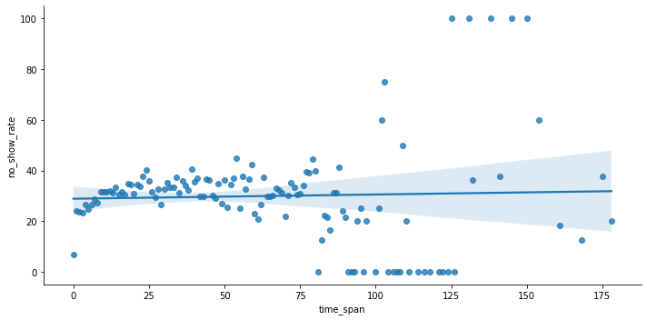

```python
# Plotting into scatter plot with regression line
#
sns.lmplot(data = df_time, x = 'time_span', y = 'no_show_rate', fit_reg = True, legend = True, aspect=2);
```

> This plot produces a trend that is difficult to see, whether it goes up or down during time_span. By using .corr() method we know that the trend is increasing along the time_span, but the value is so small.

```python
df_time.time_span.corr(df_time.no_show_rate)
```

```
0.03628525847769127
```

> It's kind of difficult to decide wheter this variable is useful or not for predict no showing patient. We need to group our data by cutting the data frame, like user tsilveira did in this [article](https://www.kaggle.com/tsilveira/applying-heatmaps-for-categorical-data-analysis).

```python
# First we need to determine the grouping category for labels
#
categories = pd.Series(['Same day: 0',
                        'Short: 1-3',
                        'Week: 4-7',
                        'Fortnight: 8-15',
                        'Month: 16-30',
                        'Quarter: 31-90',
                        'Semester: 91-180',
                        'Very long: >180'])

# Apply .cut() method on time_span column, bins is bottom value for the category above,
#
df_time['time_span'] = pd.cut(df_time.time_span, bins=[-1,0,3,7,15,30,90,180, 10000], labels=categories)

df_time_cut = df_time.groupby('time_span').sum().reset_index()
df_time_cut['no_show_rate'] = df_time_cut['Yes'] / (df_time_cut['No'] + df_time_cut['Yes']) * 100
df_time_cut
```

| no_show | time_span | No | Yes | no_show_rate |
| --- | --- | --- | --- | --- |
| 0 | Same day: 0 | 40870 | 2905 | 6.636208 |
| 1 | Short: 1-3 | 11275 | 3481 | 23.590404 |
| 2 | Week: 4-7 | 10700 | 3853 | 26.475641 |
| 3 | Fortnight: 8-15 | 8500 | 3847 | 31.157366 |
| 4 | Month: 16-30 | 10361 | 5028 | 32.672688 |
| 5 | Quarter: 31-90 | 6384 | 3161 | 33.116815 |
| 6 | Semester: 91-180 | 117 | 44 | 27.329193 |
| 7 | Very long: >180 | 0 | 0 | NaN |

```python
# Since index 7 have empty value, we can drop it.
#
df_time_cut.drop(7, inplace=True)
df_time_cut
```

| no_show | time_span | No | Yes | no_show_rate |
| --- | --- | --- | --- | --- |
| 0 | Same day: 0 | 40870 | 2905 | 6.636208 |
| 1 | Short: 1-3 | 11275 | 3481 | 23.590404 |
| 2 | Week: 4-7 | 10700 | 3853 | 26.475641 |
| 3 | Fortnight: 8-15 | 8500 | 3847 | 31.157366 |
| 4 | Month: 16-30 | 10361 | 5028 | 32.672688 |
| 5 | Quarter: 31-90 | 6384 | 3161 | 33.116815 |
| 6 | Semester: 91-180 | 117 | 44 | 27.329193 |

> Then we plot the df_time_cut into bar plot.

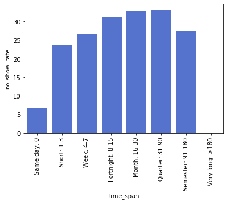

```python
g_time_span = sns.barplot(data = df_time_cut, y = 'no_show_rate', x='time_span', color='royalblue')
g_time_span.set_xticklabels(g_time_span.get_xticklabels(), rotation=90);
```

> For the same day waiting time the no show rate is so small, it' just 6.63%. Then this rate is jumped high when the waiting time is not at the same day. Starting from short term, the rate is 23.6%. This value is increasing along as waiting time increased. This trend happened until quarter term, which is the highest no show rate for time span variable, 33.11%. At the semester term the no showing rate is decreased, it's just 27.3%.

### Neighbourhood

> Same as before, we need to apply crosstab function on the neighbourhood column.

```python
df_neighbourhood = crosstab(index=df['neighbourhood'], column=df.no_show, dataframe=df, sorter=True)
df_neighbourhood.head()
```

| no_show | neighbourhood | No | Yes | no_show_rate |
| --- | --- | --- | --- | --- |
| 0 | ILHAS OCEÂNICAS DE TRINDADE | 0 | 2 | 100.000000 |
| 1 | SANTOS DUMONT | 907 | 369 | 28.918495 |
| 2 | SANTA CECÍLIA | 325 | 123 | 27.455357 |
| 3 | SANTA CLARA | 372 | 134 | 26.482213 |
| 4 | ITARARÉ | 2591 | 923 | 26.266363 |

```python
more_than_20 = df_neighbourhood.no_show_rate >= 25
df_neighbourhood[more_than_20]
```

| no_show | neighbourhood | No | Yes | no_show_rate |
| --- | --- | --- | --- | --- |
| 0 | ILHAS OCEÂNICAS DE TRINDADE | 0 | 2 | 100.000000 |
| 1 | SANTOS DUMONT | 907 | 369 | 28.918495 |
| 2 | SANTA CECÍLIA | 325 | 123 | 27.455357 |
| 3 | SANTA CLARA | 372 | 134 | 26.482213 |
| 4 | ITARARÉ | 2591 | 923 | 26.266363 |

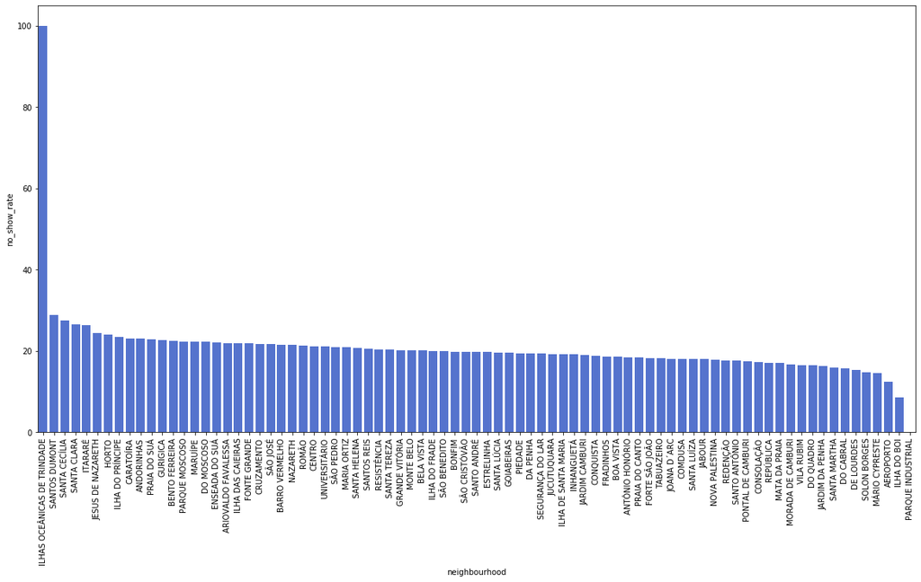

```python
plt.figure(figsize=(20, 10))
g_neighbourhood = sns.barplot(data = df_neighbourhood, y = 'no_show_rate', x='neighbourhood', color='royalblue')
g_neighbourhood.set_xticklabels(g_neighbourhood.get_xticklabels(), rotation=90);
```

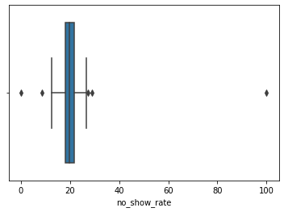

```python
sns.boxplot(x=df_neighbourhood.no_show_rate)
```

```python
df_neighbourhood.no_show_rate.mean()
```

```
20.54278744535665
```

> It's seems that almost all neighborhood has the same rate of no showing patients, the mean is 20.54%. Because the dataset is lack of information about the dataset source location or certain hospital, we cannot sure neighbourhood variable can be used for predicting.

### Appointment Weekday

> Same as before, we need to apply crosstab function on the appointment_day column.

```python
df_weekday = crosstab(index=df['appointment_weekday'], column=df.no_show, dataframe=df, sorter=False)
df_weekday.head()
```

| no_show | appointment_weekday | No | Yes | no_show_rate |
| --- | --- | --- | --- | --- |
| 0 | Friday | 14982 | 4037 | 21.226142 |
| 1 | Monday | 18024 | 4690 | 20.648058 |
| 2 | Saturday | 30 | 9 | 23.076923 |
| 3 | Thursday | 13909 | 3338 | 19.354091 |
| 4 | Tuesday | 20488 | 5152 | 20.093604 |

> We need to sort the row by weekdays, so we use .reindex() with cats list to sort it.

```python
# Make sort template
#
cats = [ 'Monday', 'Tuesday', 'Wednesday', 'Thursday', 'Friday', 'Saturday', 'Sunday']

# Applying the method
#
df_weekday = df_weekday.groupby(['appointment_weekday']).sum().reindex(cats).reset_index()
df_weekday
```

| no_show | appointment_weekday | No | Yes | no_show_rate |
| --- | --- | --- | --- | --- |
| 0 | Monday | 18024.0 | 4690.0 | 20.648058 |
| 1 | Tuesday | 20488.0 | 5152.0 | 20.093604 |
| 2 | Wednesday | 20774.0 | 5093.0 | 19.689179 |
| 3 | Thursday | 13909.0 | 3338.0 | 19.354091 |
| 4 | Friday | 14982.0 | 4037.0 | 21.226142 |
| 5 | Saturday | 30.0 | 9.0 | 23.076923 |
| 6 | Sunday | NaN | NaN | NaN |

> Then we plot it into bar plot

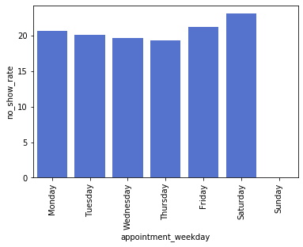

```python
g_weekday = sns.barplot(data=df_weekday, y='no_show_rate', x='appointment_weekday', color='royalblue')
g_weekday.set_xticklabels(g_weekday.get_xticklabels(), rotation=90);
```

## Conclusions

**Limitation**

> The limitation that we have in this dataset is, this dataset does not provide a certain location of the health center. Maybe the neighborhood can be a good predictor variable.

**Recommendation**

> From this dataset, people tend to come for an appointment if:
> - the waiting day is short
> - not at the weekend

> So for the health center, it's better to set the appointment day in working day with no more than one week waiting days

## Reference

- [Numpy Documentation](https://numpy.org/doc/)
- [Pandas Documentation](https://pandas.pydata.org/docs/)
- [Matplotlib Documentation](https://matplotlib.org/3.2.1/contents.html)
- [Seaborn Documentation](https://seaborn.pydata.org/index.html)
- [Applying heatmaps for categorical data analysis](https://www.kaggle.com/tsilveira/applying-heatmaps-for-categorical-data-analysis#[5])
- [Data Analyst Nanodegree project - first attempt](https://www.kaggle.com/kuroski/data-analyst-nanodegree-project-first-attempt)
- [pandas dataframe group and sort by weekday](https://stackoverflow.com/questions/47741400/pandas-dataframe-group-and-sort-by-weekday)